# Gender Data Lab Workshop in Rwanda

#### Challenge 1

Make the messy table of Parliament into a tidy format in Excel. (Hint: variables are “chamber”, “year”, “sex”, “legislators”)

$~$

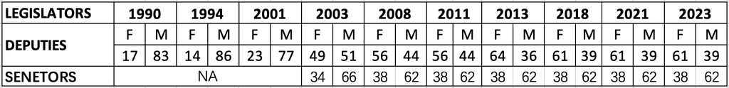

$~$

#### Challenge 2

Transform the data “ABAKOZI B’UBUSHINJACYAHA BUKURU: NPPA” into tidy format.

$~$

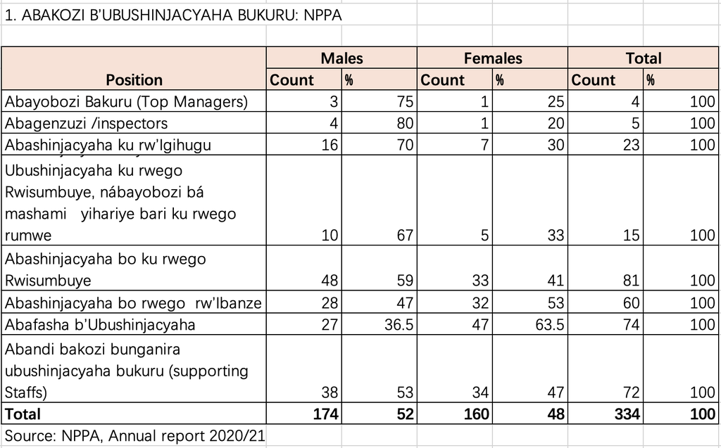

$~$

## 7. Relational Data

$~$

It’s rare that data analysis involves only a single table of data. And it’s often need to add control variables to your main data. So typically, you have many tables of data, and you must combine them to answer the questions that you’re interested in. Collectively, multiple tables of data are called relational data because it is the relations, not just the individual datasets, that are important.

$~$

Note that when we say relational database here, we are referring to how the data are structured, not to the use of any fancy software.

$~$

### 7.2 Why Relational Data

$~$

As social scientists, we are usually working with data across different **level of analysis**. The main principle of relational data is that each table is structured around the same observational unit.

$~$

Why is this important? Check out the following data.

$~$

```r
messy <- data.frame(
  county = c(36037, 36038, 36039, 36040, NA , 37001, 37002, 37003, 11001),
  state = c("NY", "NY", "NY", NA, NA, "VA", "VA", "VA", "DC"),
  county_pop = c(3817735, 422999, 324920, 143432, NA, 3228290, 449499, 383888, 689545),
  state_pop = c(43320903, 43320903, NA, 43320903, 43320903, 7173000, 7173000, 7173000, 689545),
  region = c(1, 1, 1, 1, 1, 3, 3, 3, 3)
)

kable(messy)
```

[output not shown]

$~$

$~$

If we follow the principles of relational data, each type of observational unit should form a table.

- counties contains data on counties.
- states contains data on states.

So the ideal data should look like:

```r
counties <- data.frame(
  county = c(36037, 36038, 36039, 36040, 37001, 37002, 37003, 11001),
  state = c("NY", "NY", "NY", "NY", "VA", "VA", "VA", "DC"),
  county_pop = c(3817735, 422999, 324920, 143432, 3228290, 449499, 383888, 689545), stringsAsFactors = F
)

kable(counties)

states <- data.frame(
  state = c("NY", "VA", "DC"),
  state_pop = c(43320903, 7173000, 689545),
  region = c(1, 3, 3), stringsAsFactors = F
)

kable(states)
```

[output not shown]

$~$

County population is a property of a county, so it lives in the county table. State population is a property of a state, so it cannot live in the county table. If we had panel data on counties, we would need separate tables for things that vary at the county level (like state) and things that vary at the county-year level (like population).

$~$

Now the ambiguity is gone. Every county has a population and a state. Every state has a population and a region. There are no missing states, no missing counties, and no conflicting definitions. The database is self-documenting.

$~$

What if, for some research purpose, we just need to merge these two data together, how to achieve that?

$~$

## 7.3 Keys

$~$

The variables used to connect each pair of tables are called **keys**. A key is a variable (or set of variables) that uniquely identifies an observation. Also called a unique *identifier*.

$~$

In simple cases, a single variable is sufficient to identify an observation. In the example above, each county is identified with county (a numeric identifier); each state is identified with state (a two-letter character).

$~$

There are two types of keys:

$~$

$~$

A primary key and the corresponding foreign key in another table form a **relation**.

$~$

Sometimes a table does not have an explicit primary key: each row is an observation, but it lacks a variable that reliably identifies it. If a table lacks a primary key, it is useful to add one with `mutate()`.

$~$

## 7.4 Joins

$~$

At some point, we are going to have to **merge** (or **join**) the tables together to produce a single dataframe, and conduct analysis on that dataframe.

Let’s say we wanted to merge tables `x` and `y`. A **join** allows you to combine varaibles from the two tables. It first matches observations by their keys, then copies across variables from one table to the other.

$~$

There are four join options. If our primary table is `x`, and additional table is `y`.

- 1. A `left_join` keeps all observations in `x`,
- 2. A `right_join` keeps all observations in `y`,
- 3. An `inner_join` keeps observations that appear in both tables `x` and `y`,
- 4. A `full_join` keeps all observations in `x` and all observations in `y`.

$~$

The most commonly used join is the `left_join()`: you use this whenever you look up additional data from another table, because it preserves the original observations even when there isn’t a match. For example, a `left_join()` on `x` and `y` pulls in variables form `y` while preserving all the observations on `x`.

$~$

Let’s say we want to combine the `counties` and `states` tables we created earlier.

$~$

```r
counties_states <- counties %>%
  left_join(states, by = "state")

kable(counties_states)
```

[output not shown]

$~$

Notice there are two new columns: `state_pop` and `region`.

$~$

The left join should be your default join: use it unless you have a strong reason to prefer one of the others.

$~$

## 7.5 Defining Keys

$~$

In the example above, the two tables were joined by a single variable, and that variable has the **same name** and the **same type** in both tables. That constraint was encoded by `by = "key"`.

$~$

You can use other values for `by` to connect the tables in other ways:

$~$

- 1. The default, `by = NULL`, or just leaving the `by` argument out, uses all variables that appear in both tables. And R will return a message on which variable(s) is merged by.

$~$

```r
counties_states <- counties %>%
  left_join(states)
```

$~$

- 2. A character vector, `by = c("var1", "var2")`. This sets the common variables for the joining.

$~$

- 3. A named character vector: `by = c("a" = "b")`. This will match variable `a` in table `x` to variable `b` in table `y`. The variables `a` from `x` will be used in the output.

$~$

```r
states_2 <- data.frame(
  stab = c("NY", "VA"),
  state_pop = c(43320903, 7173000),
  region = c(1, 3), stringsAsFactors = F
)

counties_states_2 <- counties %>%
  left_join(states_2, by = c("state" = "stab"))

kable(counties_states_2)
```

[output not shown]

$~$

Notice that we see NA in the last row because the `state_2` dataset does not contain observations for DC. But since we used left_join(), all observations in `counties` were preserved.

$~$

**PAY ATTENTION**: It is **very important** to check the missing values by peaking at the bottom of the dataset. Or use `table()` function with `exclude = F` to check the missing values for a specific variable.

```r
tail(counties_states_2)

table(counties_states_2$state_pop, exclude = F)
```

[output not shown]

$~$

**PAY ATTENTION**: Sometimes, even the names of the *key* variable are the same in two tables, their variable **types** are usually not the same. Then we have to check their types, by `str()` or `class()`, and coerse them to be the same type, by `as.numeric()` or `as.character()`, etc. This is very common in our day-to-day data analysis.

$~$

## 7.6 Practise with `superheroes` and `publishers`

$~$

Let’s practise how these different types of joining operations work with relational data on *comic books*. There are two data frames which contain data on comic books.

```r
superheroes <- data.frame(
  name = c("Magneto", "Storm", "Mystique", "Batman", "Joker", "Catwoman", "Sabrina"),
  alignment = c("bad", "good", "bad", "good", "bad", "bad", "good"),
  gender = c("male", "female", "female", "male", "male", "female", "female"),
  publisher = c("Marvel", "Marvel", "Marvel", "DC", "DC", "DC", "Archie Comics"),
  stringsAsFactors = F
)

publishers <- data.frame(
  publisher = c("DC", "Marvel", "Image"),
  yr_founded = c(1934, 1939, 1992),
  stringsAsFactors = F
)

superheroes
publishers
```

[output not shown]

Each data frame contains substantively different information:

- `superheroes` contains data on superheroes.
- `publishers` contains data on publishers.

The units of analysis are completely different. But depending on the type of analysis you seek to perform, it makes sense to join the data frames together temporarily.

$~$

#### i. Left Join: merge in the publisher information to the `superheroes` data. What do you find?

$~$

$~$

#### ii. Conduct a Right Join. What do you find?

$~$

$~$

#### iii. Try Inner Join this time. Which observations are left?

$~$

$~$

#### iv. Finally, perform a full join.

$~$

$~$

$~$

$~$

### Acknowledgements

This page is, in part, derived from the following sources:

1. [R for Data Science](https://r4ds.had.co.nz/) licensed under [Creative Commons Attribution-NonCommercial-NoDerivs 3.0](https://creativecommons.org/licenses/by-nc-nd/3.0/us/).
2. Rochelle Terman’s class notes for [PLSC 31101: Computational Tools for Social Science](https://plsc-31101.github.io/course/).